# Tugas Pertemuan 3 - Regresi dengan Peubah Lag

Silvia Indriyani - X1004261007

10 September 2026

# 1 Pendahuluan

Tugas ini menerapkan tiga pendekatan regresi dengan peubah lag (**Koyck**, **Distributed Lag Model/DLM**, dan **Autoregressive Distributed Lag/ARDL**) pada data kualitas udara per jam di New Delhi. Variabel dependen (Y) adalah **AQI (Air Quality Index)**, dan variabel independen (X) yang dipilih adalah **CO (Carbon Monoxide)**.

CO dipilih karena memiliki korelasi kuat namun tidak sempurna dengan AQI (sekitar 0.80), sehingga hubungan lag antar-waktu dapat dieksplorasi secara bermakna (berbeda dengan O3 yang berkorelasi hampir sempurna/quasi-deterministik dengan AQI pada data ini, atau PM10 yang korelasinya sangat lemah).

# 2 1. Persiapan Data

## 2.1 Packages

```r
# install.packages(c("dLagM", "dynlm", "MLmetrics", "lmtest", "car"))
library(dLagM)
library(dynlm)
library(MLmetrics)
library(lmtest)
library(car)
```

## 2.2 impor data & Pembagian Data

```r
# Impor Data
data <- read.csv("NewDelhi_Air_quality.csv")

# Urutkan berdasarkan waktu (ts = unix timestamp) untuk memastikan urutan kronologis
data <- data[order(data$ts), ]

# Pilih kolom yang dipakai: Y = AQI, X = CO
data <- data.frame(Yt = data$AQI, Xt = data$CO)

n <- nrow(data)
n # 72 observasi (data per jam)
```

```
## [1] 72
```

Data dibagi menjadi 58 observasi pertama untuk **Training** dan 14 observasi terakhir untuk **Testing** (proporsi kurang lebih 80:20, mengikuti pola pembagian pada modul).

```r
n_test  <- 14
n_train <- n - n_test

train <- data[1:n_train, ]
test  <- data[(n_train + 1):n, ]

train.ts <- ts(train)
test.ts  <- ts(test)
data.ts  <- ts(data)
```

# 3 2. Model Koyck

```r
model.koyck <- koyckDlm(x = train$Xt, y = train$Yt)
summary(model.koyck)
```

```
##
## Call:
## "Y ~ (Intercept) + Y.1 + X.t"
##
## Residuals:
##     Min      1Q  Median      3Q     Max
## -2.0594 -0.7171  0.1118  0.5371  2.2726
##
## Coefficients:
##             Estimate Std. Error t value Pr(>|t|)
## (Intercept) 1.650115   9.911979   0.166    0.868
## Y.1         0.911852   0.085460  10.670 6.55e-15 ***
## X.t         0.003086   0.056776   0.054    0.957
## ---
## Signif. codes:  0 '***' 0.001 '**' 0.01 '*' 0.05 '.' 0.1 ' ' 1
##
## Residual standard error: 0.9633 on 54 degrees of freedom
## Multiple R-Squared: 0.8139,  Adjusted R-squared: 0.807
## Wald test: 117.9 on 2 and 54 DF,  p-value: < 2.2e-16
##
## Diagnostic tests:
## NULL
##
##                             alpha        beta       phi
## Geometric coefficients:  18.71973 0.003086418 0.9118516
```

**Interpretasi:** Koefisien pada `Y.1` merepresentasikan parameter $\lambda$ (tingkat penurunan pengaruh masa lalu), sedangkan `X.t` merepresentasikan pengaruh langsung CO terhadap AQI pada periode yang sama. Jika p-value keduanya < 0.05, maka kedua peubah berpengaruh signifikan terhadap AQI.

## 3.1 Peramalan & Akurasi

```r
fore.koyck <- forecast(model = model.koyck, x = test$Xt, h = n_test)
fore.koyck
```

```
## $forecasts
##  [1] 23.23052 23.43042 23.61270 23.77376 23.92062 24.05454 24.17665 24.28800
##  [9] 24.38953 24.48726 24.58153 24.67265 24.76088 24.84133
##
## $call
## forecast.koyckDlm(model = model.koyck, x = test$Xt, h = n_test)
##
## attr(,"class")
## [1] "forecast.koyckDlm" "dLagM"
```

```r
mape.koyck <- MAPE(fore.koyck$forecasts, test$Yt)
cat("MAPE Model Koyck:", mape.koyck, "\n")
```

```
## MAPE Model Koyck: 0.1370419
```

# 4 3. Distributed Lag Model (DLM)

## 4.1 Penentuan Lag Optimum

Pencarian lag optimum $q$ dilakukan dengan `finiteDLMauto()` berdasarkan AIC terkecil.

```r
q.search <- finiteDLMauto(formula = Yt ~ Xt,
                           data = data.frame(train), q.min = 1, q.max = 8,
                           model.type = "dlm", error.type = "AIC", trace = TRUE)
q.search
```

```
##   q - k    MASE      AIC      BIC    GMRAE    MBRAE R.Adj.Sq    Ljung-Box
## 8     8 1.06658 156.8234 177.8556 18837.93  0.05585  0.78656 1.590823e-02
## 7     7 1.33336 180.5029 199.8212 20418.70  0.06402  0.68114 3.046921e-03
## 6     6 1.46633 197.7025 215.2637 17811.92 -3.45588  0.57122 3.703213e-05
## 5     5 1.65291 210.1633 225.9257 21457.68  0.13138  0.47804 1.537231e-07
## 4     4 1.84421 216.5591 230.4820 34360.90  2.18078  0.43568 1.081398e-08
## 3     3 1.93920 220.8850 232.9289 32422.79  0.57923  0.42049 4.434820e-10
## 2     2 1.84853 221.9900 232.1167 25647.88  0.14415  0.42972 1.024816e-09
## 1     1 1.83815 225.7193 233.8915 20586.68  1.86318  0.41390 2.330515e-09
```

```r
# Ambil q dengan AIC terkecil
q_opt <- as.numeric(rownames(q.search)[which.min(q.search$AIC)])
q_opt
```

```
## [1] 8
```

## 4.2 Pemodelan dengan Lag Optimum

```r
model.dlm.opt <- dlm(x = train$Xt, y = train$Yt, q = q_opt)
summary(model.dlm.opt)
```

```
##
## Call:
## lm(formula = model.formula, data = design)
##
## Residuals:
##      Min       1Q   Median       3Q      Max
## -3.16197 -0.35666  0.09446  0.55485  2.61190
##
## Coefficients:
##              Estimate Std. Error t value Pr(>|t|)
## (Intercept) -58.77904   12.58839  -4.669 3.37e-05 ***
## x.t           0.64685    0.12867   5.027 1.09e-05 ***
## x.1           0.08598    0.21109   0.407    0.686
## x.2          -0.27734    0.20884  -1.328    0.192
## x.3           0.11669    0.21927   0.532    0.598
## x.4           0.11207    0.21467   0.522    0.605
## x.5          -0.27804    0.22142  -1.256    0.217
## x.6           0.08739    0.20938   0.417    0.679
## x.7          -0.07856    0.20739  -0.379    0.707
## x.8           0.01296    0.11978   0.108    0.914
## ---
## Signif. codes:  0 '***' 0.001 '**' 0.01 '*' 0.05 '.' 0.1 ' ' 1
##
## Residual standard error: 1.042 on 40 degrees of freedom
## Multiple R-squared:  0.8258, Adjusted R-squared:  0.7866
## F-statistic: 21.06 on 9 and 40 DF,  p-value: 1.57e-12
##
## AIC and BIC values for the model:
##        AIC      BIC
## 1 156.8234 177.8556
```

## 4.3 Peramalan & Akurasi

```r
fore.dlm.opt <- forecast(model = model.dlm.opt, x = test$Xt, h = n_test)
mape.dlm.opt <- MAPE(fore.dlm.opt$forecasts, test$Yt)
cat("MAPE Model DLM Optimum (q =", q_opt, "):", mape.dlm.opt, "\n")
```

```
## MAPE Model DLM Optimum (q = 8 ): 0.09685061
```

# 5 4. Autoregressive Distributed Lag (ARDL)

## 5.1 Penentuan Lag Optimum (p, q)

```r
model.ardl.search <- ardlBoundOrders(data = data.frame(data), ic = "AIC",
                                      formula = Yt ~ Xt)

min_p <- c()
for (i in 1:length(model.ardl.search$Stat.table)) {
  min_p[i] <- min(model.ardl.search$Stat.table[[i]])
}
q_opt_ardl <- which(min_p == min(min_p, na.rm = TRUE))
p_opt_ardl <- which(model.ardl.search$Stat.table[[q_opt_ardl]] ==
                       min(model.ardl.search$Stat.table[[q_opt_ardl]], na.rm = TRUE))

data.frame("Lag_Y_opt(q)" = q_opt_ardl, "Lag_X_opt(p)" = p_opt_ardl,
           "AIC" = model.ardl.search$min.Stat)
```

```
##   Lag_Y_opt.q. Lag_X_opt.p.      AIC
## 1            6           15 121.7055
```

## 5.2 Pemodelan dengan Lag Optimum

```r
model.ardl.opt <- ardlDlm(formula = Yt ~ Xt, data = train,
                           p = p_opt_ardl, q = q_opt_ardl)
summary(model.ardl.opt)
```

```
##
## Time series regression with "ts" data:
## Start = 16, End = 58
##
## Call:
## dynlm(formula = as.formula(model.text), data = data)
##
## Residuals:
##     Min      1Q  Median      3Q     Max
## -0.9952 -0.2896 -0.0151  0.2838  1.0531
##
## Coefficients:
##               Estimate Std. Error t value Pr(>|t|)
## (Intercept) -37.738678  25.777908  -1.464  0.15874
## Xt.t          0.100829   0.125246   0.805  0.43026
## Xt.1          0.172038   0.162424   1.059  0.30214
## Xt.2         -0.250258   0.154648  -1.618  0.12127
## Xt.3          0.115715   0.168583   0.686  0.50034
## Xt.4         -0.002981   0.172001  -0.017  0.98634
## Xt.5         -0.222555   0.174061  -1.279  0.21568
## Xt.6          0.465809   0.178663   2.607  0.01686 *
## Xt.7         -0.115778   0.199679  -0.580  0.56851
## Xt.8         -0.115196   0.196775  -0.585  0.56481
## Xt.9          0.161327   0.201070   0.802  0.43178
## Xt.10        -0.050085   0.205278  -0.244  0.80973
## Xt.11        -0.007636   0.189122  -0.040  0.96819
## Xt.12        -0.049576   0.169784  -0.292  0.77330
## Xt.13        -0.018367   0.153463  -0.120  0.90593
## Xt.14         0.136581   0.148264   0.921  0.36792
## Xt.15        -0.068572   0.090655  -0.756  0.45822
## Yt.1          0.990306   0.260784   3.797  0.00113 **
## Yt.2          0.033996   0.330984   0.103  0.91921
## Yt.3         -0.055343   0.327050  -0.169  0.86732
## Yt.4          0.015561   0.331545   0.047  0.96303
## Yt.5         -0.401547   0.344496  -1.166  0.25749
## Yt.6         -0.053909   0.253678  -0.213  0.83386
## ---
## Signif. codes:  0 '***' 0.001 '**' 0.01 '*' 0.05 '.' 0.1 ' ' 1
##
## Residual standard error: 0.6536 on 20 degrees of freedom
## Multiple R-squared:  0.9586, Adjusted R-squared:  0.9131
## F-statistic: 21.06 on 22 and 20 DF,  p-value: 1.853e-09
```

## 5.3 Peramalan & Akurasi

```r
fore.ardl <- forecast(model = model.ardl.opt, x = test$Xt, h = n_test)
mape.ardl <- MAPE(fore.ardl$forecasts, test$Yt)
cat("MAPE Model ARDL Optimum (p =", p_opt_ardl, ", q =", q_opt_ardl, "):",
    mape.ardl, "\n")
```

```
## MAPE Model ARDL Optimum (p = 15 , q = 6 ): 0.08409193
```

# 6 5. Evaluasi Asumsi Model

Uji asumsi dilakukan pada model setara ARDL optimum menggunakan `dynlm`, karena outputnya kompatibel dengan `lmtest`.

```r
# Model setara ARDL optimum menggunakan dynlm (sesuaikan urutan lag L() dengan p_opt_ardl & q_opt_ardl)
cons_lm <- dynlm(Yt ~ L(Xt, 0:p_opt_ardl) + L(Yt, 1:q_opt_ardl), data = train.ts)
summary(cons_lm)
```

```
##
## Time series regression with "ts" data:
## Start = 16, End = 58
##
## Call:
## dynlm(formula = Yt ~ L(Xt, 0:p_opt_ardl) + L(Yt, 1:q_opt_ardl),
##     data = train.ts)
##
## Residuals:
##     Min      1Q  Median      3Q     Max
## -0.9952 -0.2896 -0.0151  0.2838  1.0531
##
## Coefficients:
##                         Estimate Std. Error t value Pr(>|t|)
## (Intercept)           -37.738678  25.777908  -1.464  0.15874
## L(Xt, 0:p_opt_ardl)0    0.100829   0.125246   0.805  0.43026
## L(Xt, 0:p_opt_ardl)1    0.172038   0.162424   1.059  0.30214
## L(Xt, 0:p_opt_ardl)2   -0.250258   0.154648  -1.618  0.12127
## L(Xt, 0:p_opt_ardl)3    0.115715   0.168583   0.686  0.50034
## L(Xt, 0:p_opt_ardl)4   -0.002981   0.172001  -0.017  0.98634
## L(Xt, 0:p_opt_ardl)5   -0.222555   0.174061  -1.279  0.21568
## L(Xt, 0:p_opt_ardl)6    0.465809   0.178663   2.607  0.01686 *
## L(Xt, 0:p_opt_ardl)7   -0.115778   0.199679  -0.580  0.56851
## L(Xt, 0:p_opt_ardl)8   -0.115196   0.196775  -0.585  0.56481
## L(Xt, 0:p_opt_ardl)9    0.161327   0.201070   0.802  0.43178
## L(Xt, 0:p_opt_ardl)10  -0.050085   0.205278  -0.244  0.80973
## L(Xt, 0:p_opt_ardl)11  -0.007636   0.189122  -0.040  0.96819
## L(Xt, 0:p_opt_ardl)12  -0.049576   0.169784  -0.292  0.77330
## L(Xt, 0:p_opt_ardl)13  -0.018367   0.153463  -0.120  0.90593
## L(Xt, 0:p_opt_ardl)14   0.136581   0.148264   0.921  0.36792
## L(Xt, 0:p_opt_ardl)15  -0.068572   0.090655  -0.756  0.45822
## L(Yt, 1:q_opt_ardl)1    0.990306   0.260784   3.797  0.00113 **
## L(Yt, 1:q_opt_ardl)2    0.033996   0.330984   0.103  0.91921
## L(Yt, 1:q_opt_ardl)3   -0.055343   0.327050  -0.169  0.86732
## L(Yt, 1:q_opt_ardl)4    0.015561   0.331545   0.047  0.96303
## L(Yt, 1:q_opt_ardl)5   -0.401547   0.344496  -1.166  0.25749
## L(Yt, 1:q_opt_ardl)6   -0.053909   0.253678  -0.213  0.83386
## ---
## Signif. codes:  0 '***' 0.001 '**' 0.01 '*' 0.05 '.' 0.1 ' ' 1
##
## Residual standard error: 0.6536 on 20 degrees of freedom
## Multiple R-squared:  0.9586, Adjusted R-squared:  0.9131
## F-statistic: 21.06 on 22 and 20 DF,  p-value: 1.853e-09
```

## 6.1 Uji Autokorelasi (Durbin-Watson)

H0: Tidak ada autokorelasi

```r
dwtest(cons_lm)
```

```
##
##  Durbin-Watson test
##
## data:  cons_lm
## DW = 1.8405, p-value = 0.1557
## alternative hypothesis: true autocorrelation is greater than 0
```

## 6.2 Uji Heteroskedastisitas (Breusch-Pagan)

H0: Ragam sisaan homogen

```r
bptest(cons_lm)
```

```
##
##  studentized Breusch-Pagan test
##
## data:  cons_lm
## BP = 20.862, df = 22, p-value = 0.5293
```

## 6.3 Uji Normalitas (Shapiro-Wilk)

H0: Sisaan berdistribusi normal

```r
shapiro.test(residuals(cons_lm))
```

```
##
##  Shapiro-Wilk normality test
##
## data:  residuals(cons_lm)
## W = 0.99474, p-value = 0.9993
```

*(Catatan: Tolak H0 jika P-Value < 0.05. Jika salah satu asumsi tidak terpenuhi, transformasi data atau spesifikasi lag ulang dapat dipertimbangkan.)*

# 7 6. Perbandingan Performa Model

## 7.1 Deviance Model

Deviance (jumlah kuadrat sisaan/RSS) dihitung dari model hasil training untuk melihat seberapa baik masing-masing model mewakili data historis (bukan data testing).

```r
dev.koyck    <- sum(residuals(model.koyck$model)^2)
dev.dlm.opt  <- sum(residuals(model.dlm.opt$model)^2)
dev.ardl     <- sum(residuals(model.ardl.opt$model)^2)

deviance.tbl <- matrix(c(dev.koyck, dev.dlm.opt, dev.ardl))
row.names(deviance.tbl) <- c("Koyck", paste0("DLM Optimum (q=", q_opt, ")"),
                              paste0("ARDL Optimum (p=", p_opt_ardl, ",q=", q_opt_ardl, ")"))
colnames(deviance.tbl) <- c("Deviance")
print(deviance.tbl)
```

```
##                          Deviance
## Koyck                   50.106749
## DLM Optimum (q=8)       43.406679
## ARDL Optimum (p=15,q=6)  8.543034
```

## 7.2 Ringkasan Akurasi (MAPE) dan Deviance

```r
akurasi <- matrix(c(mape.koyck, mape.dlm.opt, mape.ardl,
                     dev.koyck, dev.dlm.opt, dev.ardl), ncol = 2)
row.names(akurasi) <- c("Koyck", paste0("DLM Optimum (q=", q_opt, ")"),
                         paste0("ARDL Optimum (p=", p_opt_ardl, ",q=", q_opt_ardl, ")"))
colnames(akurasi) <- c("MAPE", "Deviance")
print(akurasi)
```

```
##                               MAPE  Deviance
## Koyck                   0.13704186 50.106749
## DLM Optimum (q=8)       0.09685061 43.406679
## ARDL Optimum (p=15,q=6) 0.08409193  8.543034
```

Model dengan nilai **MAPE terkecil** dianggap memiliki performa peramalan terbaik pada data testing (data baru/di luar training), sedangkan **deviance terkecil** menunjukkan model yang paling baik menjelaskan (fit) data training itu sendiri. Karena Koyck, DLM, dan ARDL menggunakan jumlah observasi training efektif yang berbeda (bergantung pada orde lag masing-masing), perbandingan deviance di sini bersifat indikatif, bukan mutlak.

## 7.3 Visualisasi Aktual vs Peramalan

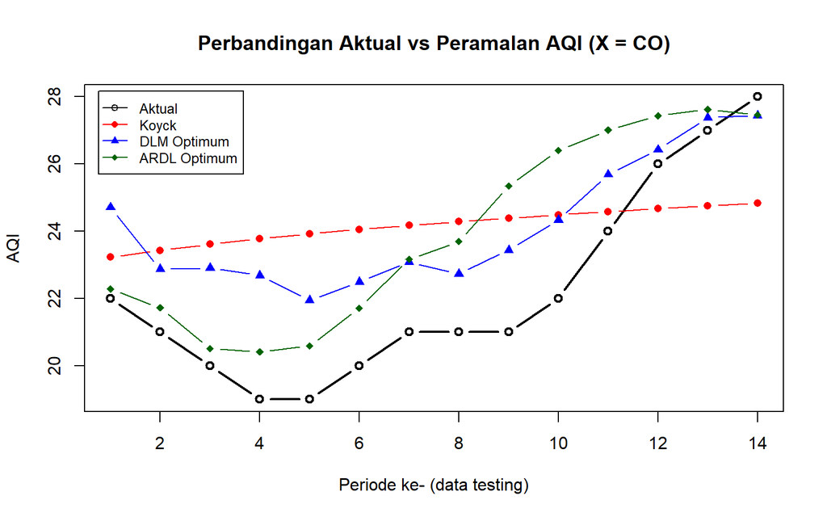

```r
par(mfrow = c(1, 1))
plot(1:n_test, test$Yt, type = "b", col = "black", lwd = 2,
     ylim = range(c(test$Yt, fore.koyck$forecasts, fore.dlm.opt$forecasts, fore.ardl$forecasts)),
     ylab = "AQI", xlab = "Periode ke- (data testing)",
     main = "Perbandingan Aktual vs Peramalan AQI (X = CO)")
lines(1:n_test, fore.koyck$forecasts, col = "red", type = "b", pch = 16)
lines(1:n_test, fore.dlm.opt$forecasts, col = "blue", type = "b", pch = 17)
lines(1:n_test, fore.ardl$forecasts, col = "darkgreen", type = "b", pch = 18)
legend("topleft", legend = c("Aktual", "Koyck", "DLM Optimum", "ARDL Optimum"),
       col = c("black", "red", "blue", "darkgreen"), lty = 1,
       pch = c(1, 16, 17, 18), cex = 0.8, inset = 0.02)
```

# 8 7. Kesimpulan

Berdasarkan hasil analisis di atas, model **ARDL Optimum (p = 15, q = 6)** memberikan performa peramalan terbaik pada data testing dengan MAPE sebesar **0,084 (8,4%)**, lebih kecil dibandingkan model DLM Optimum (q = 8) dengan MAPE 0,097 (9,7%) dan model Koyck dengan MAPE 0,137 (13,7%). Urutan performa peramalan dari yang terbaik ke terburuk adalah ARDL > DLM > Koyck.

Evaluasi asumsi sisaan dilakukan pada model setara ARDL optimum (melalui `dynlm`) dan ketiga asumsi klasik terpenuhi:

- **Autokorelasi (Durbin-Watson):** DW = 1,8405, p-value = 0,1557 (> 0,05) sehingga H0 tidak ditolak — tidak terdapat autokorelasi pada sisaan.
- **Heteroskedastisitas (Breusch-Pagan):** BP = 20,862, p-value = 0,5293 (> 0,05) sehingga H0 tidak ditolak — ragam sisaan homogen.
- **Normalitas (Shapiro-Wilk):** W = 0,99474, p-value = 0,9993 (> 0,05) sehingga H0 tidak ditolak — sisaan berdistribusi normal.

Karena seluruh asumsi klasik terpenuhi, model ARDL optimum ini dapat dikatakan valid secara statistik dan layak digunakan untuk interpretasi maupun peramalan.

Dari sisi interpretasi hubungan lag, orde ARDL optimum (p = 15, q = 6) menunjukkan bahwa pengaruh CO terhadap AQI tidak bersifat instan, melainkan terakumulasi hingga sekitar 15 jam ke belakang (lag pada variabel CO), sementara nilai AQI itu sendiri juga masih dipengaruhi oleh nilai AQI pada 6 jam sebelumnya (lag pada variabel dependen). Hal ini mengindikasikan bahwa efek polutan CO terhadap kualitas udara bersifat kumulatif dan cenderung bertahan cukup lama (belasan jam) sebelum pengaruhnya sepenuhnya terserap ke dalam indeks AQI, sehingga peningkatan konsentrasi CO pada suatu waktu berpotensi masih memengaruhi kualitas udara beberapa jam ke depan.